# IODS course project

Yurii Batrak

# Introduction to Open Data Science - Course Project

# About the project

This is an introductory course on open data science which intends to teach students the modern approaches in reproducible research. The main tool in this course is the **R** programming language, a *de-facto* standard in the statistical research and processing applicatinos. Moreover, modern best practices in research suggest sharing not only the final result of the study by make it in a easy-to-reproduce way. For studies perfromed mainly with the R language this could be achieved by using the **Rmarkdown** format for reportimg. Rmarkdown includes both the R source code, explanations and comments in formatted text form as well as the output of the R code. One of the goals of this course is to show the students how to utilise these powerful instruments in the best way and encourage them to apply these techniques in their research.

My personal expectations from this course are quite high. I hope I would be able to get a bit of fluency in R and apply some of the covered approaches in my research.

The project repository: https://github.com/joewkr/IODS-project

# Regression and model validation

*A short summary and things learned*

- In the exercise we investigate data from a survey taken by students of a statistics course
- We study how to prepare and explore data sets in R
- For deeper understanding of the data set structure we build a linear model predicting the grade on the final exam
- Quality assessment of the obtained model is given a special attention

First of all, we load the data set which we are going to work with. This is a preporcessed data set which provides information about the survey taken by students of a statistics course and it also includes the grades received after the course.

```r
learning2014 <- read.csv('learning2014.csv')
dim(learning2014)
```

```
## [1] 166   7
```

This data set provides information about 166 students for 7 available parameters. These parameters include student’s age and gender, general attitude towards statistics, their replies to survey questions combined in a four categories, and the total number of points obtained during the final exam of the course. Structure of the data set and a sample subset could be obtained with the following command:

```r
str(learning2014)
```

```
## 'data.frame':    166 obs. of  7 variables:
##  $ gender  : Factor w/ 2 levels "F","M": 1 2 1 2 2 1 2 1 2 1 ...
##  $ age     : int  53 55 49 53 49 38 50 37 37 42 ...
##  $ attitude: num  3.7 3.1 2.5 3.5 3.7 3.8 3.5 2.9 3.8 2.1 ...
##  $ deep    : num  3.58 2.92 3.5 3.5 3.67 ...
##  $ stra    : num  3.38 2.75 3.62 3.12 3.62 ...
##  $ surf    : num  2.58 3.17 2.25 2.25 2.83 ...
##  $ points  : int  25 12 24 10 22 21 21 31 24 26 ...
```

For a general quick overview of the data set we could use the `pairs` function to generate a simple scatter plot figure comparing all the variables against each other.

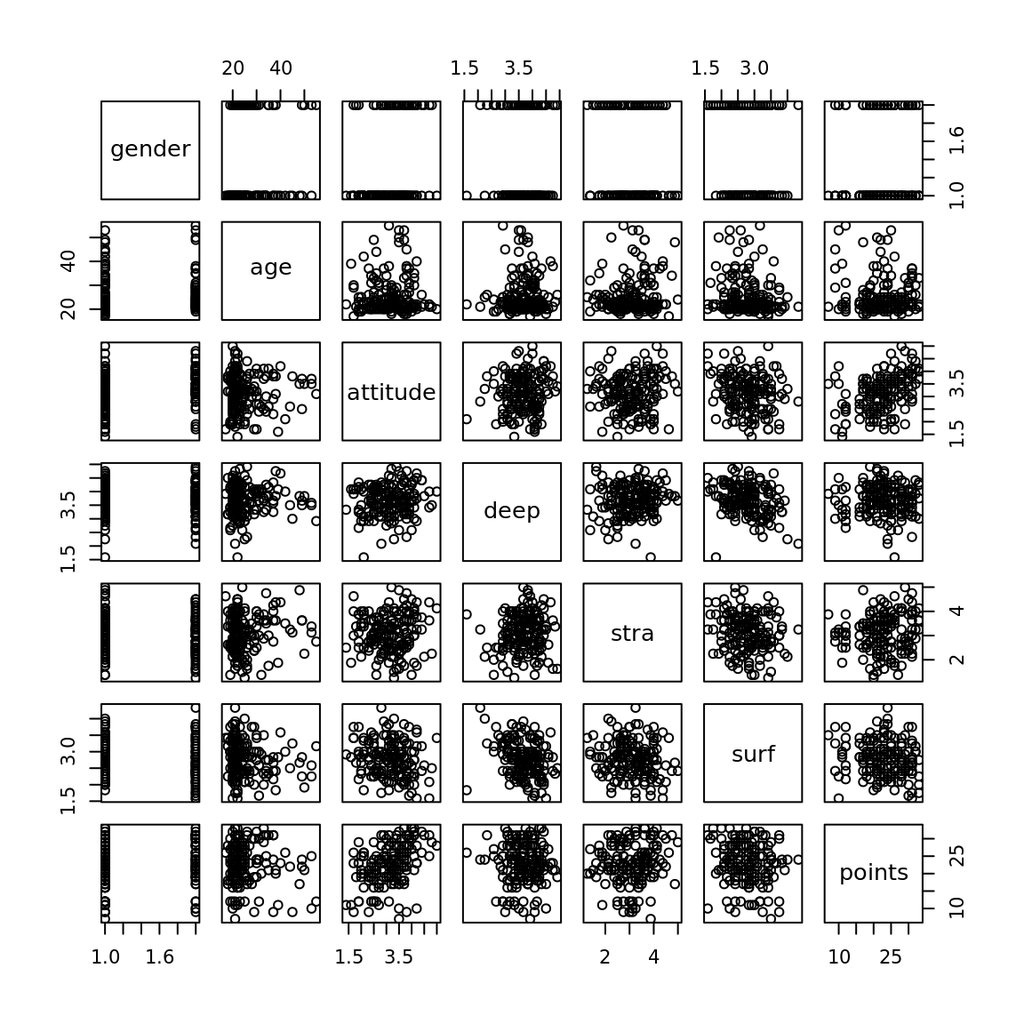

```r
pairs(learning2014)
```

The `points` column is of primary interest for us because it provides information about student grades on the exam. As can be seen from the figure there is no easy to spot dependency between exam points and other variables except the `attitude`. The `age` column seems to have some interesting features as well, though less pronounced. The majority of students was in their twenties as can will be evident from the estimated distribution function introduced further down in the text. And this big group of students received all the possible grades from very low to high. But if we focus on the older student we could see that for them there seems to be negative correlation between their age and points received at the exam.

To get a more clear overview of dependencies between different variables it is often useful to have also some numerical measure, for example, correlation coefficient to complement scatter plots. Here we calculate correlations between all the numeric variables in the data set:

```r
numeric_columns <- tail(names(learning2014))
cor(learning2014[numeric_columns])
```

```
##                  age    attitude        deep        stra       surf      points
## age       1.00000000  0.02220071  0.02507804  0.10244409 -0.1414052 -0.09319032
## attitude  0.02220071  1.00000000  0.11024302  0.06174177 -0.1755422  0.43652453
## deep      0.02507804  0.11024302  1.00000000  0.09650255 -0.3238020 -0.01014849
## stra      0.10244409  0.06174177  0.09650255  1.00000000 -0.1609729  0.14612247
## surf     -0.14140516 -0.17554218 -0.32380198 -0.16097287  1.0000000 -0.14435642
## points   -0.09319032  0.43652453 -0.01014849  0.14612247 -0.1443564  1.00000000
```

The correlation matrix shows that students which planned to not get too deep into the topic of the course (i.e. the students with high `surf` score) tend to receive lower grades on the exam. Surprisingly, the students whom indicate in their surveys that they strive to get deeper understanding of the topic (high score in the `deep` group) did not show better (or worse) exam grades than other student groups. Except the students with high general attitude towards statistics, only the students which tend to use systematic and organized approach to studying (high `stra` score) were able to get better scores on the final exam.

Another insight on the data set could be obtained from the estimated distributions of the numerical variables:

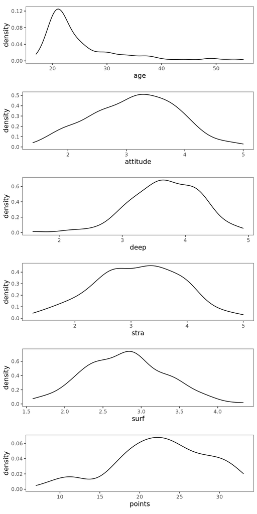

```r
i <- 1
for(c in tail(names(learning2014))) {
  p <- ggally_densityDiag(learning2014, mapping = aes_string(x=c)) +
       theme_bw() +
       theme(panel.grid.major=element_blank(), panel.grid.minor=element_blank(), aspect.ratio=0.25)

  var_name <- paste('p', i, sep='')
  assign(var_name, p)
  i <- i + 1
}

grid.arrange(p1, p2, p3, p4, p5, p6, nrow = 6)
```

There it is clear that the majority of students taken the survey are around 20 year old and there is not too many older students in the group. Distributions for the `surf` and `deep` scores show somewhat opposite picture with `surf` tending to have lower values and `deep` – higher. I guess to some extent this could be caused by the human factor since the questions in the `deep` group tend to represent a *good* student while questions in the `surf` group describe a *somewhat lazy* person. Also an interesting observation there is less probability of getting 13…15 points on the exam than nearby values which could be caused by some peculiarities of the grading system.

Finally we could provide the overall summary of the data set which supports the earlier observations:

```r
summary(learning2014)
```

```
##  gender       age           attitude          deep            stra
##  F:110   Min.   :17.00   Min.   :1.400   Min.   :1.583   Min.   :1.250
##  M: 56   1st Qu.:21.00   1st Qu.:2.600   1st Qu.:3.333   1st Qu.:2.625
##          Median :22.00   Median :3.200   Median :3.667   Median :3.188
##          Mean   :25.51   Mean   :3.143   Mean   :3.680   Mean   :3.121
##          3rd Qu.:27.00   3rd Qu.:3.700   3rd Qu.:4.083   3rd Qu.:3.625
##          Max.   :55.00   Max.   :5.000   Max.   :4.917   Max.   :5.000
##       surf           points
##  Min.   :1.583   Min.   : 7.00
##  1st Qu.:2.417   1st Qu.:19.00
##  Median :2.833   Median :23.00
##  Mean   :2.787   Mean   :22.72
##  3rd Qu.:3.167   3rd Qu.:27.75
##  Max.   :4.333   Max.   :33.00
```

So, which variables could be used to build a linear model for predicting the exam grade? Obviously, attitude should be included since it shows the highest correlation with the exam points. But both `deep` and `surf` groups seem to be influenced by human factor making them less applicable for this modeling exercise, unlike the `stra` group (which also has the second-highest correlation with the exam points). Therefore for building the model we take `attitude`, `stra` and `age` since it shows some interesting features for the older students.

```r
model <- lm(points ~ attitude + stra + age, data = learning2014)
summary(model)
```

```
##
## Call:
## lm(formula = points ~ attitude + stra + age, data = learning2014)
##
## Residuals:
##      Min       1Q   Median       3Q      Max
## -18.1149  -3.2003   0.3303   3.4129  10.7599
##
## Coefficients:
##             Estimate Std. Error t value Pr(>|t|)
## (Intercept) 10.89543    2.64834   4.114 6.17e-05 ***
## attitude     3.48077    0.56220   6.191 4.72e-09 ***
## stra         1.00371    0.53434   1.878   0.0621 .
## age         -0.08822    0.05302  -1.664   0.0981 .
## ---
## Signif. codes:  0 '***' 0.001 '**' 0.01 '*' 0.05 '.' 0.1 ' ' 1
##
## Residual standard error: 5.26 on 162 degrees of freedom
## Multiple R-squared:  0.2182, Adjusted R-squared:  0.2037
## F-statistic: 15.07 on 3 and 162 DF,  p-value: 1.07e-08
```

The summary information of the fitted model provides basic overview about the fitted model and gives important information about the statistical significance of the assumed dependency between the target and explanatory variables. For each of the explanatory variables the significance test provides probability of getting the observed values of the target variable if the explanatory variable in question is has random values. As a consequence, when the p-value is high it is less likely that target variable depends on that explanatory variable. For our model, only the `attitude` parameter shows very low p-value of 4.72e-09 which indicates strong and significant dependency between the exam point and students attitude. The other two explanatory variables `stra` and `age`, with p-values of 0.0621 and 0.0981 though still significant assuming the significance level $\alpha$ = 0.10 show much weaker connection between them and the target variable.

The obtained linear model which is written as:

$$\text{points} = 10.9 + 3.481\cdot\text{attitude} + 1.004\cdot\text{stra} -0.08822\cdot\text{age}$$
shows that with higher `attitude` and `stra` scores, students would tend getting higher final exam grade. Although for the older students the negative `age` coefficient indicates that these students tend to have lower final exam grade than younger students with the same `attitude` and `stra` scores.

Another important parameters provided in the summary of our model is the multiple R-squared value which shows how good is the fit of our model. The low value of the multiple R-squared parameter indicate that only about the 20% of variation in the exam grades could be explained by the selected set of explanatory variables. However, this parameter does not indicate whether the selected set of the explanatory variables is optimal or not.

To estimate how good the assumptions taken when fitting the linear model hold we use the following series of diagnostic plots:

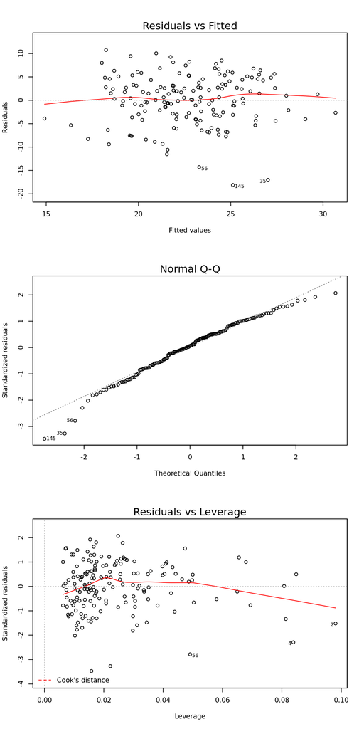

```r
par(mfrow=c(3,1))
plot(model, which=c(1,2,5))
```

There the ‘Residuals vs Fitted’ plot shows the dependency between the fitted model values and residuals calculated as a difference between the observed values and fitted. A sound model should show no clear dependency between the residuals and fitted values. The produced model seems to have reasonable residuals which are more or less evenly distributed across the range of fitted values. Although the worrying point there is the cluster of numbered points (35, 56 and 145) having somewhat larger residual values.

The same pattern could observed on the ‘Normal Q-Q’ plot as well. This plot indicates how well the assumption of normal distribution of the residuals is held (ideally the points should lay on the 1:1 line there). Again on a seemingly reasonable plot the cluster of numbered points could indicate potential issues with the model.

Finally, the ‘Residuals vs Leverage’ plot shows how much weight is given to individual observations when fitting the model. For a well-defined model this plot should not show outlier points with high leverage values. Our model seems to fit reasonably well under this assumption, though it still shows some numbered points. But these points have a relatively low leverage value thus making it a bit less of an issue.

# Logistic regression

*A short summary and things learned*

- In the exercise we use the information about students of two Portuguese schools to build a statistical model for predicting which students would show high alcohol consumption
- For modeling a binary target variable we use logistic regression
- Model quality is assessed by investigating prediction and training errors
- In attempt to find a better set of explanatory variables we probe randomly selected models to minimize the prediction error

Again, before we start the analysis we load the data set from the file system. This data set provides information about students of two Portuguese schools and their achievements. It contains received grades (variables `G1`, `G2` and `G3`) as well as students background including social and school-related information. The original data set could be obtained via the following link https://archive.ics.uci.edu/ml/datasets/Student+Performance and detailed description of the data set variables is also provided. Although the original data set was provided separately for two subjects: Mathematics and Portuguese language, in the current study a preprocessed data set is used. Ths data set is obtained by merging the original data sets.

Variables in the perprocessed data set could be shown by applying the `names` function to the loaded data frame:

```r
alc <- read.csv('alc.csv')
dim(alc)
```

```
## [1] 382  35
```

```r
names(alc)
```

```
##  [1] "school"     "sex"        "age"        "address"    "famsize"
##  [6] "Pstatus"    "Medu"       "Fedu"       "Mjob"       "Fjob"
## [11] "reason"     "nursery"    "internet"   "guardian"   "traveltime"
## [16] "studytime"  "failures"   "schoolsup"  "famsup"     "paid"
## [21] "activities" "higher"     "romantic"   "famrel"     "freetime"
## [26] "goout"      "Dalc"       "Walc"       "health"     "absences"
## [31] "G1"         "G2"         "G3"         "alc_use"    "high_use"
```

As could be seen from the output, this data set introduces two additional variables, namely `alc_use` which is a simple mean of `Dalc` and `Walc`, and `high_use` which indicates relatively high alcohol consumption by a student and defined to be TRUE when `alc_use` takes values greater than the threshold value of `2`.

Since the data set provides quite extensive information about students it could be possible to build a statistical model predicting high alcohol consumption based on these data. For this study I choose the four following variables:

```r
selected_columns <- c('famrel', 'studytime', 'absences', 'goout')
```

where `famrel` describes quality of student’s family relationships (with higher values corresponding to better relationships), `studytime` describes how much time students spends on their studies over a week, `absences` descries the number of times when a student was absent from school, and `goout` describes how often a students goes out with friends.

I expect these variables to be connected to the alcohol consumption since it would be natural to assume that a person with bad family relationships who does not spend too much time studying, often absent and going out with friends would show higher alcohol consumption.

To get a better overview of the selected variables and study their possible connection to the alchol consumption a graphical summary could be of a great help.

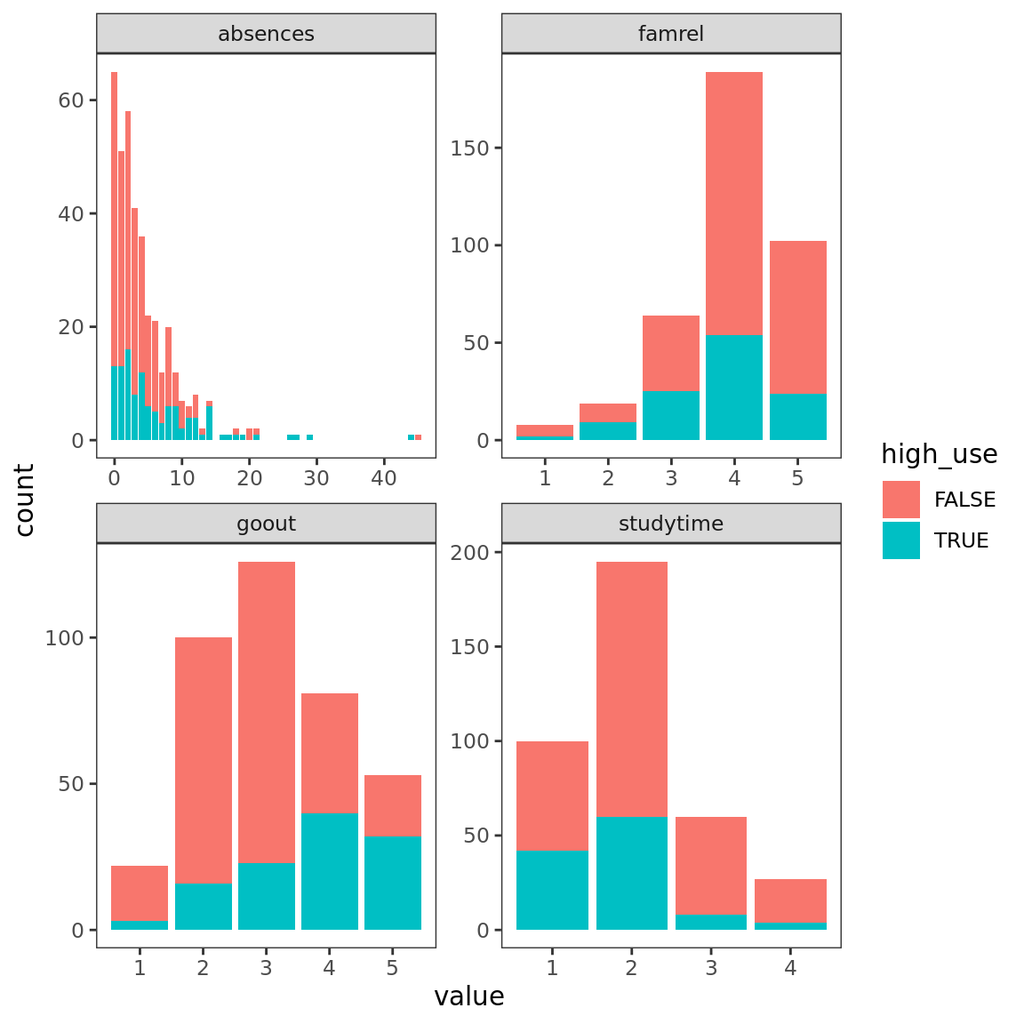

```r
alc %>%
pivot_longer(all_of(selected_columns), names_to='key', values_to='value') %>%
ggplot(aes(value, fill=high_use)) +
  facet_wrap("key", scales = "free") +
  geom_bar() +
  theme_bw() +
  theme(panel.grid.major=element_blank(), panel.grid.minor=element_blank())
```

The bar plots of the selected variables show no striking features supporting the initial hypothesis. Although the `goout` tends to have higher values for students who have high alcohol consumption. Surprisingly the `absences` does not seem to show peaks of high absence for students with high alcohol consumption but rather features a gradual increase of drinkers fraction with increasing days of absence. For the `studytime` variable the fraction of students with high alcohol consumption greatly diminishes with increasing number of hours spent on studies. And finally `famrel` shows a somewhat similar picture with relatively less number of drinking students in families with good relationships.

This information could also be provided in tabular form which supports the conclusions drawn from the graphs:

```r
for(var in selected_columns) {
  print(table(alc[c('high_use', var)]))
}
```

```
##         famrel
## high_use   1   2   3   4   5
##    FALSE   6  10  39 135  78
##    TRUE    2   9  25  54  24
##         studytime
## high_use   1   2   3   4
##    FALSE  58 135  52  23
##    TRUE   42  60   8   4
##         absences
## high_use  0  1  2  3  4  5  6  7  8  9 10 11 12 13 14 16 17 18 19 20 21 26 27
##    FALSE 52 38 42 33 24 16 16  9 14  6  5  2  4  1  1  0  0  1  0  2  1  0  0
##    TRUE  13 13 16  8 12  6  5  3  6  6  2  4  4  1  6  1  1  1  1  0  1  1  1
##         absences
## high_use 29 44 45
##    FALSE  0  0  1
##    TRUE   1  1  0
##         goout
## high_use   1   2   3   4   5
##    FALSE  19  84 103  41  21
##    TRUE    3  16  23  40  32
```

To predict the high alcohol consumption based on the selected variables a logistical model could be applied:

```r
f_string <- paste('high_use ~ ', paste(selected_columns, collapse = ' + '))
model <- glm(as.formula(f_string), data = alc, family = "binomial")
summary(model)
```

```
##
## Call:
## glm(formula = as.formula(f_string), family = "binomial", data = alc)
##
## Deviance Residuals:
##     Min       1Q   Median       3Q      Max
## -1.8701  -0.7738  -0.5019   0.8042   2.5416
##
## Coefficients:
##             Estimate Std. Error z value Pr(>|z|)
## (Intercept) -1.28606    0.70957  -1.812  0.06992 .
## famrel      -0.33699    0.13681  -2.463  0.01377 *
## studytime   -0.55089    0.16789  -3.281  0.00103 **
## absences     0.06753    0.02175   3.104  0.00191 **
## goout        0.75953    0.12041   6.308 2.82e-10 ***
## ---
## Signif. codes:  0 '***' 0.001 '**' 0.01 '*' 0.05 '.' 0.1 ' ' 1
##
## (Dispersion parameter for binomial family taken to be 1)
##
##     Null deviance: 465.68  on 381  degrees of freedom
## Residual deviance: 384.07  on 377  degrees of freedom
## AIC: 394.07
##
## Number of Fisher Scoring iterations: 4
```

Summary of the trained model indicate that all the selected predictors have statistically significant relations with the target variable `high_use` taking the significance level $\alpha = 0.05$. Coefficients of the model suggest that `absences` has the weakest connection with the target variable whereas the other selected explanatory variables show a more strong link.

A bit more insight on the characteristics of the obtained model could be learned by studying the coefficients in form of odd ratios and providing their confidence intervals:

```r
odds_ratio <- model %>% coef    %>% exp
confidence <- model %>% confint %>% exp
cbind(odds_ratio, confidence)
```

```
##             odds_ratio      2.5 %    97.5 %
## (Intercept)  0.2763573 0.06723596 1.0961732
## famrel       0.7139151 0.54460646 0.9331198
## studytime    0.5764343 0.41040872 0.7941804
## absences     1.0698631 1.02591583 1.1187950
## goout        2.1372720 1.69853389 2.7261579
```

this table shows that for `famrel` and `studytime` odds ratios are below one (namely, 0.714 and 0.576) which means that increasing these parameters would decrease the probability of student being a drinker. Contrary, the odds ratios for `absences` and `goout` are above one thus increasing these parameters would increase the probability of high alcohol consumption by a student. Another important observation from this table is that the confidence intervals for all the odds ratios do not include 1 meaning that these odds ratios are significant. This is true also for the `absences` variable which has the odds ratio of 1.07, which is rather close to 1 but still significant.

To investigate the predictive power of our model it could be used to estimate the probability of high alcohol consumption from the same data set which was applied to train the model. To do so, the `predict` function can be used and if the resulting probability is higher than 0.5 a student is assumed to be a drinker. This information combined with the actual data on alcohol consumption allows generating the cross tabulation of predicted vs actual values:

```r
probabilities <- predict(model, type = "response")
alc <- alc %>% mutate(probability = probabilities, prediction = probability > 0.5)

table(high_use = alc$high_use, prediction = alc$prediction)
```

```
##         prediction
## high_use FALSE TRUE
##    FALSE   242   26
##    TRUE     65   49
```

This table shows an interesting property of the model, it tends to predict the low alcohol consumption better than high one i.e. it gives a considerably high number of false negatives. This property of the model is apparent from the following plot:

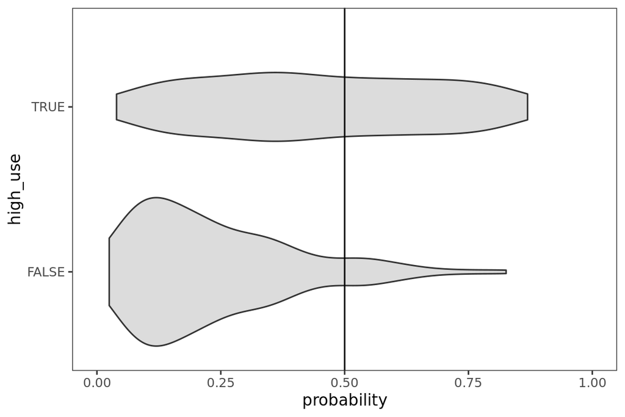

```r
alc %>%
ggplot(aes(x = probability, y = high_use)) +
  geom_violin(trim = TRUE, fill='#DCDCDC') +
  geom_vline(xintercept = 0.5) +
  xlim(0,1) +
  theme_bw() +
  theme(panel.grid.major=element_blank(), panel.grid.minor=element_blank())
```

it is evident that for students having low alcohol consumption the model tends to predict consistent low probability of being a drinker. From the other side for drinking students the model yields a somewhat close to uniform distribution of predictions showing no predictive skill.

The total proportion of the failed predictions (i.e. the training error) could be calculated in the following way by taking a simple average of model predictions:

```r
loss_func <- function(class, prob) {
  n_wrong <- abs(class - prob) > 0.5
  mean(n_wrong)
}

loss_func(class = alc$high_use, prob = alc$probability)
```

```
## [1] 0.2382199
```

which gives a value of 0.238 meaning that about a quarter of the predictions were incorrect.

Such an approach which uses the whole data set to train a model and the to test it, though simple and straightforward, gives a biased estimate of model quality because all the data points which are used for testing are already ‘known’ to the model since they were used for training. A more robust approach takes only a part of the data set for training the model and keeps a part of it for testing. This approach is applied in the `cv.glm` function which estimates the model prediction error in presence of unknown observations. There the data set is divided into 10 chunks and only 9 of them are used for model training when the last one is used for validation. This procedure is repeated for all combinations of training and validation chunks returning a K-fold cross-validation prediction error.

```r
cv <- cv.glm(data = alc, cost = loss_func, glmfit = model, K = 10)
cv$delta[1]
```

```
## [1] 0.2434555
```

For the model built in the current exercise the cross-validation procedure gives the prediction error of 0.243 which is higher than the previous estimate because it uses unknown to the model data for validation. This error is lower than the error of the example model (it uses the following formula: `high_use ~ sex + failures + absences`) given for this course which was about 0.26.

But giving a relatively big number of potential explanatory variables it is not a straightforward task to select the best set for building a model. A naïve solution would be testing all the possible combinations of the explanatory variables and taking a model which gives the lowest prediction error. The problem is that for a data set with 34 free parameters the number of possible combinations of explanatory variables would be:

$$C = \sum_r^{34} \frac{34!}{r!\cdot(34 - r)!} \equiv 1.7179869\times 10^{10}$$
which renders this idea rather impractical. But to assess the properties of models built with different explanatory variables using only a minor fraction of all possible combinations would suffice. Therefore to investigate the models built with various combinations of different number of explanatory variables the following approach is applied. For each size of the explanatory vector a random selection of the explanatory variables is used to train a model and obtain the model training and prediction errors. This procedure is repeated `N` times for each explanatory vector size to get multiple model realizations. For each model the model formula, size of the explanatory vector, prediction and training errors are stored in the final data frame for the following analysis.

```r
possible_predictors <- head(names(alc), n = -3)
possible_predictors <- possible_predictors[! possible_predictors %in% c('Walc', 'Dalc', 'alc_use')]

mdf <- data.frame(numeric(0), logical(0), numeric(0), character(0), stringsAsFactors = FALSE)
names(mdf) <- c('size', 'training', 'error', 'model')

num_possible_predictors <- length(possible_predictors)
for(i in 30:1) {
  # Do not test all the combinations for models with more than
  # three predictors, it takes way too much time.
  if(i <= 3) {
    selected_predictors <- gtools::combinations(
        n=num_possible_predictors
      , r=i
      , v=possible_predictors
      , repeats.allowed=FALSE)
  } else {
    selected_predictors <- t(replicate(400, sample(possible_predictors, size = i)))
  }

  for(r in 1:nrow(selected_predictors)) {
    predictors <- selected_predictors[r,]

    f_string <- paste('high_use ~ ', paste(predictors, collapse = '+'))
    m <- tryCatch(
      glm(as.formula(f_string), data = alc, family = "binomial"),
      error=function(e){return(NULL)},
      warning=function(w) {return(NULL)})

    if(!is.null(m)) {
      # Calculate training error
      alc_loc <- data.frame(alc)
      p <- predict(m, type = "response")
      alc_loc <- alc_loc %>% mutate(probability = p, prediction = probability > 0.5)
      loss <- loss_func(class = alc_loc$high_use, prob = alc_loc$probability)

      cv <- cv.glm(data = alc_loc, cost = loss_func, glmfit = m, K = 10)

      # Store training and testing errors
      mdf[nrow(mdf) + 1,] <- list(i, TRUE,  loss,        f_string)
      mdf[nrow(mdf) + 1,] <- list(i, FALSE, cv$delta[1], f_string)
    }
  }
}
```

As could be seen from the summary figure, the model errors tend to become smaller with increasing the size of the explanatory vector (there `training` indicates training errors if TRUE and prediction errors if FALSE). This could be attributed to the non-totality of the selected approach which makes it easier to draw a set of ‘bad’ variables if the explanatory vector is short. From the other side for long explanatory vectors there is a higher probability of getting ‘good’ variables from a random draw.

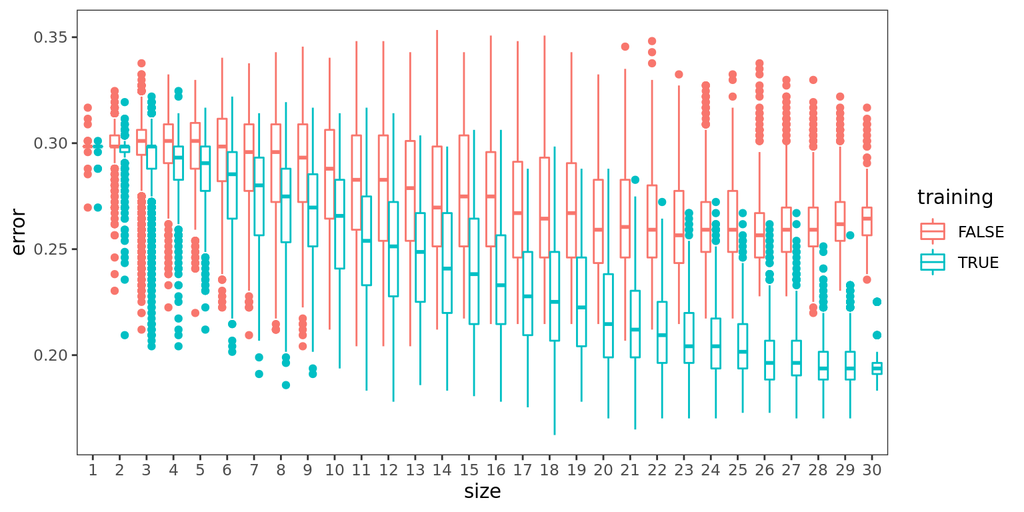

```r
mdf$size <- as.factor(mdf$size)
mdf %>%
ggplot(aes(x = size, y = error, col=training)) +
  geom_boxplot() +
  theme_bw() +
  theme(panel.grid.major=element_blank(), panel.grid.minor=element_blank())
```

From all the tested models, the following give the lowest prediction error:

```r
mdf[mdf$training == FALSE,] %>% slice_min(error)
```

```
##   size training     error
## 1   13    FALSE 0.2041885
## 2    9    FALSE 0.2041885
##                                                                                                   model
## 1 high_use ~  activities+Mjob+internet+studytime+absences+paid+sex+reason+nursery+Fedu+age+goout+higher
## 2                               high_use ~  reason+G2+activities+famsup+absences+sex+goout+Medu+nursery
```

The model with the the lowest prediction error (there the model with fewer explanatory variables was taken) shows some improvement in the prediction skill though still tends to give a considerable amount of false negative predictions according to the provided summary:

```r
best_score <- mdf[mdf$training == FALSE,] %>% slice_min(error)
best_formula <- as.formula(best_score$model[2])
better_model <- glm(as.formula(best_formula), data = alc, family = "binomial")
summary(better_model)
```

```
##
## Call:
## glm(formula = as.formula(best_formula), family = "binomial",
##     data = alc)
##
## Deviance Residuals:
##     Min       1Q   Median       3Q      Max
## -2.0255  -0.7642  -0.4861   0.8064   2.7573
##
## Coefficients:
##                  Estimate Std. Error z value Pr(>|z|)
## (Intercept)      -3.51951    0.82443  -4.269 1.96e-05 ***
## reasonhome        0.18904    0.32007   0.591 0.554773
## reasonother       1.09637    0.45591   2.405 0.016182 *
## reasonreputation -0.20941    0.35264  -0.594 0.552630
## G2               -0.02247    0.04843  -0.464 0.642723
## activitiesyes    -0.47083    0.26752  -1.760 0.078409 .
## famsupyes         0.04418    0.27130   0.163 0.870655
## absences          0.08698    0.02364   3.679 0.000234 ***
## sexM              1.03519    0.27176   3.809 0.000139 ***
## goout             0.76352    0.12690   6.017 1.78e-09 ***
## Medu             -0.03218    0.12743  -0.253 0.800646
## nurseryyes       -0.45547    0.32090  -1.419 0.155799
## ---
## Signif. codes:  0 '***' 0.001 '**' 0.01 '*' 0.05 '.' 0.1 ' ' 1
##
## (Dispersion parameter for binomial family taken to be 1)
##
##     Null deviance: 465.68  on 381  degrees of freedom
## Residual deviance: 373.58  on 370  degrees of freedom
## AIC: 397.58
##
## Number of Fisher Scoring iterations: 4
```

```r
p2 <- predict(better_model, type = "response")
a2 <- data.frame(alc)
a2 <- a2 %>% mutate(probability = p2, prediction = probability > 0.5)

table(high_use = a2$high_use, prediction = a2$prediction)
```

```
##         prediction
## high_use FALSE TRUE
##    FALSE   251   17
##    TRUE     57   57
```

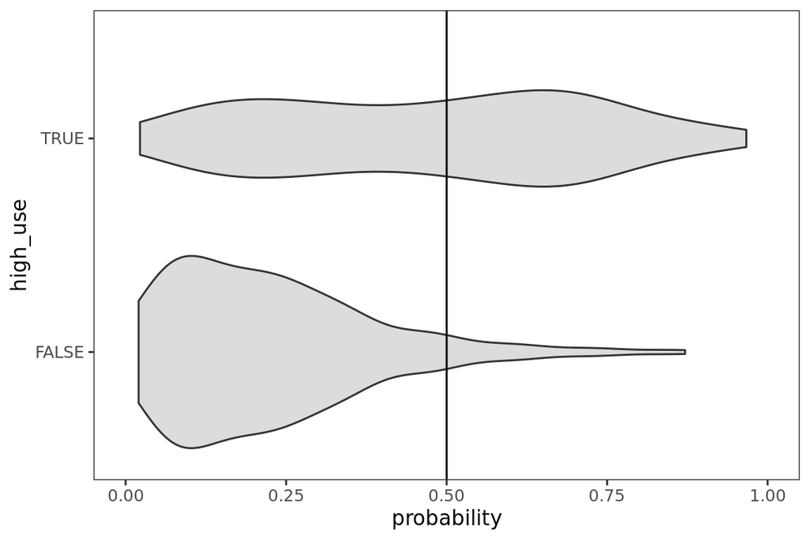

```r
a2 %>%
ggplot(aes(x = probability, y = high_use)) +
  geom_violin(trim = TRUE, fill='#DCDCDC') +
  geom_vline(xintercept = 0.5) +
  xlim(0,1) +
  theme_bw() +
  theme(panel.grid.major=element_blank(), panel.grid.minor=element_blank())
```

(more chapters to be added similarly as we proceed with the course!)